# Kruskal Wallis

2023-03-19

## 1. Child wellbeing scores

We are working in a hospital unit and have been posted in a pediatric unit. Every few hours, a nurse is asked to assess the condition of patients in the unit. Condition is scored on an ordinal Likert scale: 5 codes for very good, 3 for neither good nor bad, and 1 for very bad. We have three patients which have been assessed 10 times each. Their scores are contained in the `child` dataset. We want to know, do their scores differ?

Note: There are multiple ways to do this!

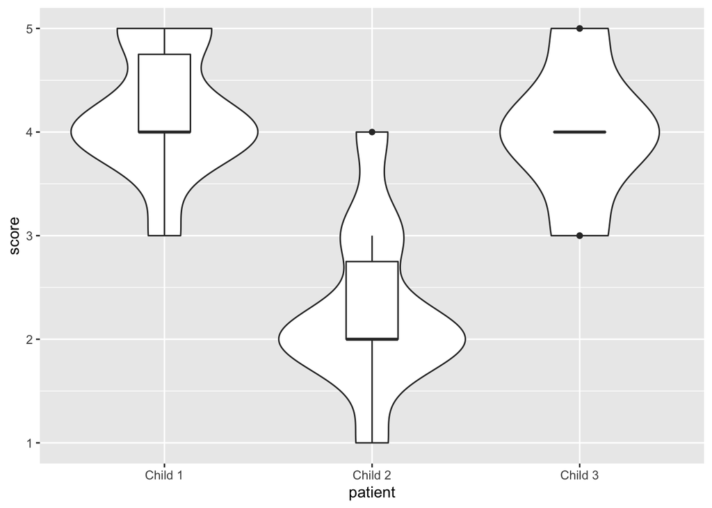

```r
ggplot(child, aes(x = patient, y = score))+
  geom_violin()+
  geom_boxplot(width = 0.25)
```

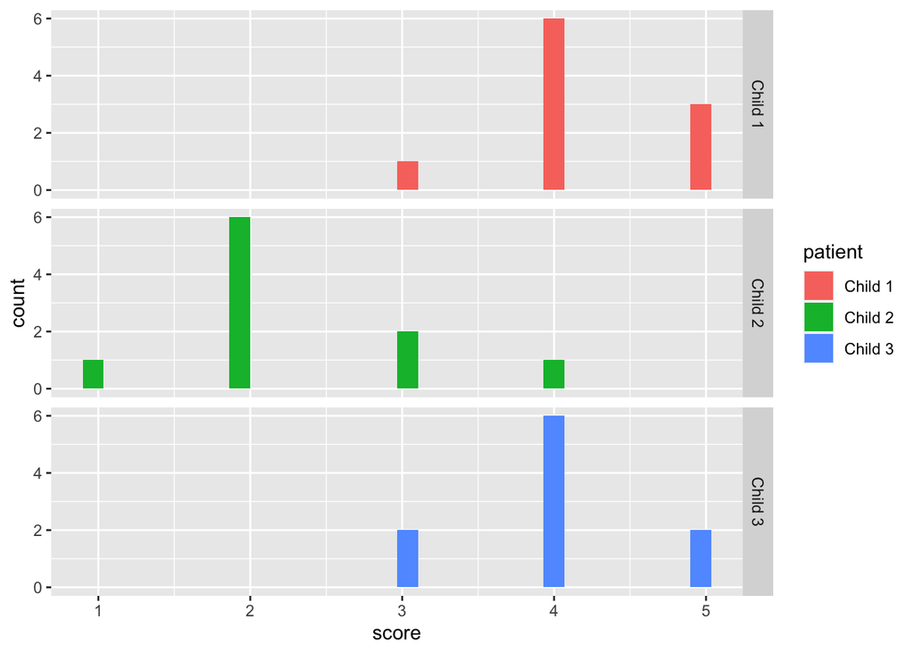

```r
ggplot(child, aes(x = score, fill = patient))+
  geom_histogram(position = "dodge")+
  facet_grid(patient ~ .)
```

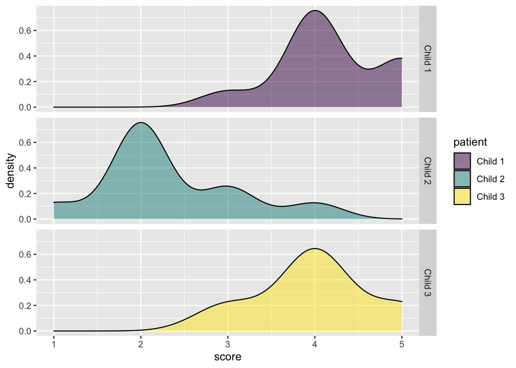

```r
ggplot(child, aes(x = score, fill = patient))+
  geom_density(alpha = 0.5)+
   facet_grid(patient ~ .)+
  scale_fill_viridis_d()
```

#### Q1.3. Assess normality of scores for each patient. Should we use a parametric or non-parametric test?

Non-parametric

```r
child1 <- filter(child, patient == "Child 1")
shapiro.test(child1$score)
```

```
##
##  Shapiro-Wilk normality test
##
## data:  child1$score
## W = 0.79406, p-value = 0.01228
```

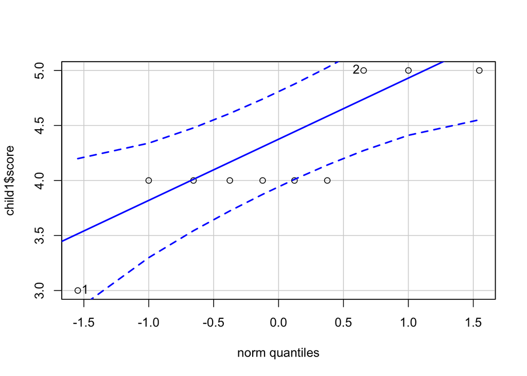

```
## [1] 1 2
```

```r
qqPlot(child1$score)
```

```r
child2 <- filter(child, patient == "Child 2")
shapiro.test(child2$score)
```

```
##
##  Shapiro-Wilk normality test
##
## data:  child2$score
## W = 0.84062, p-value = 0.04489
```

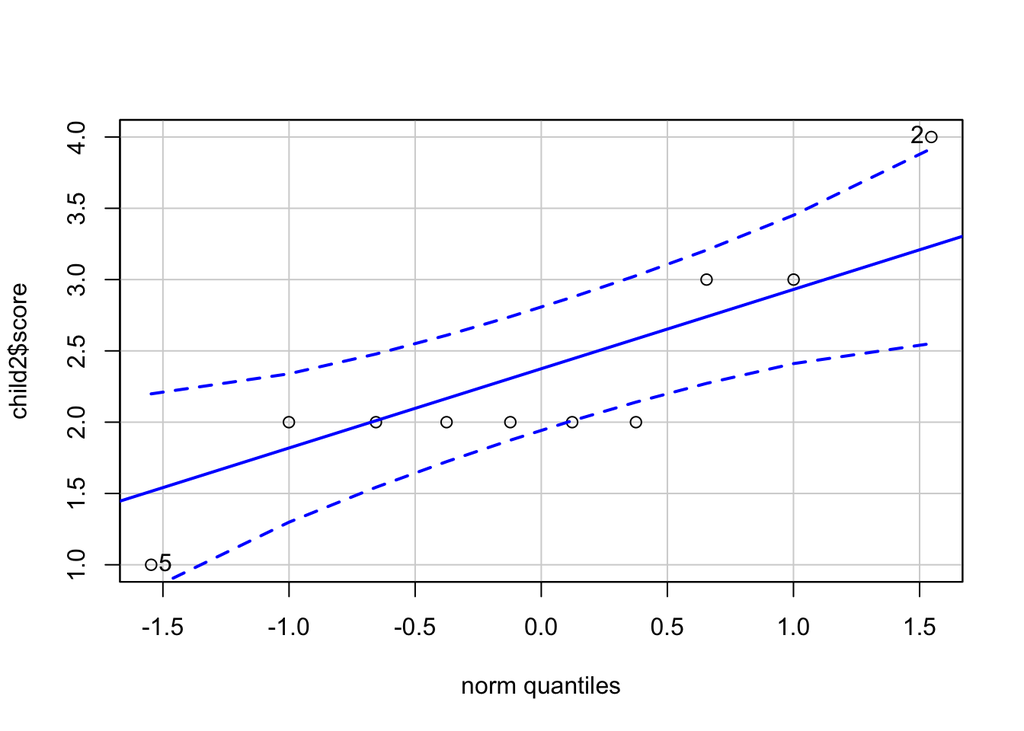

```
## [1] 2 5
```

```r
qqPlot(child2$score)
```

```r
child3 <- filter(child, patient == "Child 3")
shapiro.test(child3$score)
```

```
##
##  Shapiro-Wilk normality test
##
## data:  child3$score
## W = 0.81484, p-value = 0.02195
```

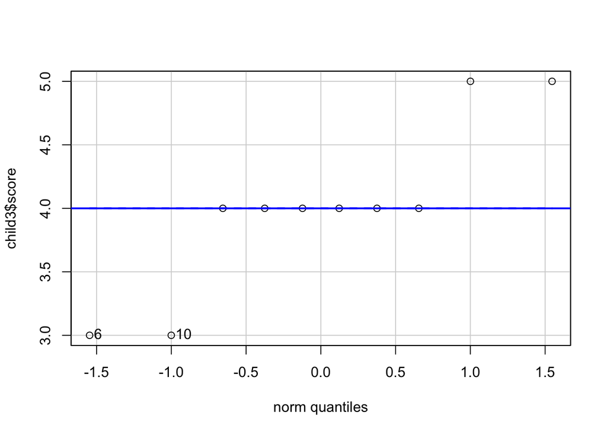

```
## [1]  6 10
```

```r
qqPlot(child3$score)
```

#### Q1.3. Which type of non-parametric test should we use?

Kruskal Wallis because we have three groups

#### Q1.4. State the null and alternate hypotheses

H<sub>0</sub>: The median observation scores do not differ across patients

H<sub>1</sub>: The median observation scores **DO** differ across patients

#### Q1.5. Run the test

```r
kruskal.test(score ~ patient, data = child)
```

```
##
##  Kruskal-Wallis rank sum test
##
## data:  score by patient
## Kruskal-Wallis chi-squared = 16.842, df = 2, p-value = 0.0002202
```

#### Q1.6. Conclude on your null hypothesis:

Reject the null hypothesis ( p <0.05)

#### Q1.7. Which group(s) differ from the others and in what direction? You might use here the Dunn test as well as your initial plot to help you interpret the Dunn test

Child 2 is different, child 2 has lower scores than child 1 or 3 which have similar scores

```r
dunnTest(score ~ patient, data = child, method = "bh")
```

```
## Dunn (1964) Kruskal-Wallis multiple comparison
```

```
##   p-values adjusted with the Benjamini-Hochberg method.
```

```
##          Comparison          Z      P.unadj        P.adj
## 1 Child 1 - Child 2  3.7702412 0.0001630898 0.0004892695
## 2 Child 1 - Child 3  0.4813074 0.6302980448 0.6302980448
## 3 Child 2 - Child 3 -3.2889338 0.0010056766 0.0015085149
```